# **Ficha resumen semanal de incididencia delictiva de mujeres**

###### Ficha informativa: 18 de octubre de 2022

Esta ficha resumen, muestra el total de carpetas reportadas en los municipios de Jalisco por el Secretariado Ejecutivo del Sistemana Nacional de Seguridad Pública[^1], los datos utilizados corresponden a la fecha de juliode2022 y sólo se muestra el comportamiento de los delitos que se consideran por razón de género: feminicidio, homicidio doloso, muertes violentas, abuso sexual, violación y violencia familiar. [^1]: *La última actualización de la base de datos corresponde al mes de julio de 2022*

# Feminicidio

Las cifras de feminicidio que se observan desde 2015 tuvieron su punto más bajo en el periodo correspondiente a 2016, 2017 y 2018 mientras que en **2021** se vivió el mayor número de feminicidios con un total de **73**. Actualmente, la cifra hasta **julio** de **2022** asciende a **17** , con un patrón de comportamiento numérico por debajo de los tres años anteriores.

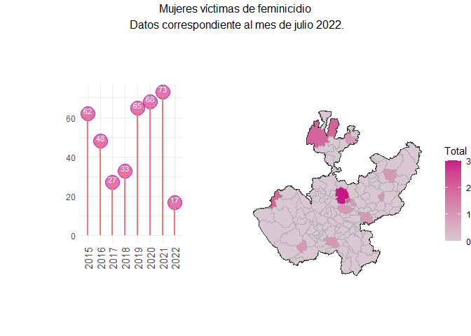

# Homicidio doloso

En cuanto a homicidio doloso, por un lado se observa que el año con mayor incidencia fue **2019** con **2017** homicidios dolosos de mujeres. Por el otro lado, los primeros años del periodo, 2015 a 2017 es cuando se observa menor cantidad de homicidios dolosos, siendo 2015 el menor de todos con 957. Hasta el mes de **julio** de **2022** la cifra total es de **918** con **142** homicidios solo en **julio**.

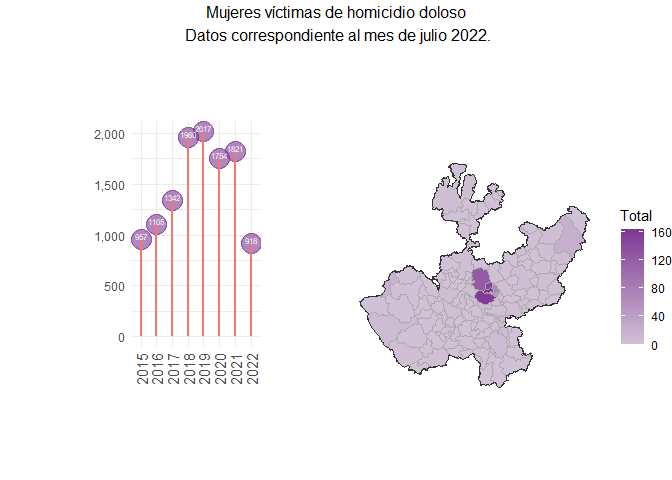

# Muertes violentas

La cifra de muertes violentas de mujeres se calcula sumando el total de homicidios dolosos y feminicidios en un año. Se observa que la violencia homicida y feminicida alcanzó su mayor nivel en **2019** con **2082** muertes violentas de mujeres en Jalisco. En **2022** se observa un total de **935** con **142** en el mes de **julio**.

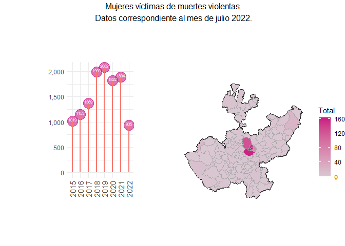

# Abuso sexual

A diferencia de los delitos anteriores, las cifras de Abuso Sexual no varían significativamente entre los años analizados, siendo **2019** el mes con mayor incidencia con **2423** casos. La única excepción ocurre en 2015 donde se observaron 1572 casos de abuso sexual. La suma hasta el mes de **julio** del **2022** es de **1625** con **272** casos en el último mes del análisis.

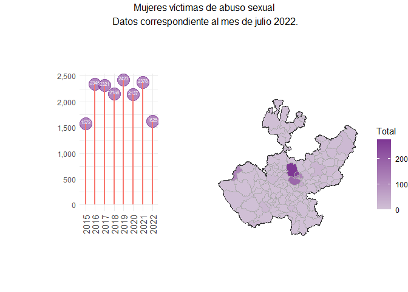

# Violencia familiar

Las cifras de mujeres que han sido víctimas de violencia familiar en los últimos años superan los 8000 casos por año desde 2015, alcanzando el máximo de **12620** casos en **2021**. A comparación de los años anteriores, se observa un patrón desacelerado para **2022**, pues hasta ahora se ha dado un total de **7592** casos con **1042** hasta el mes de **julio**.

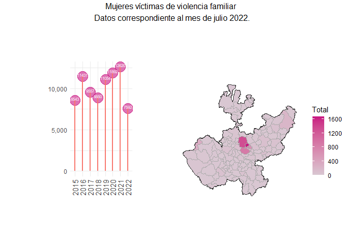

# Violación

El promedio del número de violaciones en los últimos siete años en Jalisco es de 440 aproximadamente, considerando ambas, violación simple y equiparada. Se observa que en 2015, 2018 y 2020 se dieron menos de 400 casos anuales y más de 400 en 2016, 2017, 2019. En **2021** se dió el nivel más alto del periodo con **517** casos. En lo que va del **2022**, se han registrado un total de **277** casos con **37** en el último mes de **julio**.

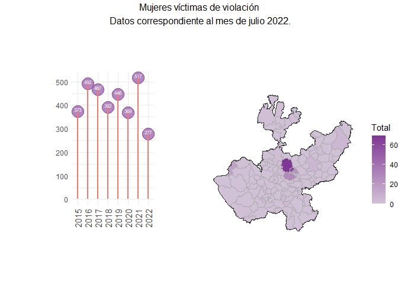